# Regression with the California Housing Dataset

#### Dataset Description

The dataset for this competition (both train and test) was generated from a deep learning model trained on the California Housing Dataset. Feature distributions are close to, but not exactly the same, as the original. Feel free to use the original dataset as part of this competition, both to explore differences as well as to see whether incorporating the original in training improves model performance.

Files

- train.csv - the training dataset; MedHouseVal is the target
- test.csv - the test dataset; your objective is to predict MedHouseVal
- sample_submission.csv - a sample submission file in the correct format

Data is synthetic

**Features:**

- **MedInc**, Median Income in block group

**House Characteristics**

- **HouseAge**, median house age in block group
- **AveRooms**, average number of rooms per household
- **AveBedrms**, average number of bedrooms per household
- **AveOccup**, average number of household members

**Spatial Features**

- **Latitude** and **Longitude**, block group latitude and longitude
- **Population**, block group population

**Target Feature**

- **MedHouseVal**, feature to predict, Median House Value

We're also told that the dataset was "derived from the `1990 U.S. census`"" and that they define a **block** to be "the smallest geographical unit for which the U.S. Census Bureau publishes sample data (a block group typically has a population of 600 to 3,000 people).".

#### Evaluation - Root Mean Squared Error (RMSE)

Submissions are scored on the root mean squared error.

# Import Libraries

```python
import pandas as pd
import matplotlib.pyplot as plt

import tensorflow as tf
from tensorflow.keras import layers
import seaborn as sns

from sklearn.datasets import fetch_california_housing
```

# Exploratory Data Analysis

```python
data_train = pd.read_csv('/kaggle/input/playground-series-s3e1/train.csv', index_col='id')
data_test = pd.read_csv('/kaggle/input/playground-series-s3e1/test.csv', index_col='id')
features = data_train.columns[:-1]
```

```python
original_df, original_y = fetch_california_housing(return_X_y=True)
original_df = pd.DataFrame(original_df, columns=features)
original_df['MedHouseVal'] = original_y
```

```python
data_train.shape[0], data_test.shape[0], original_df.shape[0]
```

```
(37137, 24759, 20640)
```

```python
data_train.describe()
```

|  | MedInc | HouseAge | AveRooms | AveBedrms | Population | AveOccup | Latitude | Longitude | MedHouseVal |
| --- | --- | --- | --- | --- | --- | --- | --- | --- | --- |
| count | 37137.000000 | 37137.000000 | 37137.000000 | 37137.000000 | 37137.000000 | 37137.000000 | 37137.000000 | 37137.000000 | 37137.000000 |
| mean | 3.851029 | 26.057005 | 5.163124 | 1.062204 | 1660.778919 | 2.831243 | 35.570030 | -119.554329 | 2.079751 |
| std | 1.803167 | 12.158221 | 1.206242 | 0.096490 | 1302.469608 | 2.702413 | 2.083179 | 1.974028 | 1.158571 |
| min | 0.499900 | 2.000000 | 0.851064 | 0.500000 | 3.000000 | 0.950000 | 32.550000 | -124.350000 | 0.149990 |
| 25% | 2.602300 | 17.000000 | 4.357522 | 1.020305 | 952.000000 | 2.394495 | 33.930000 | -121.800000 | 1.208000 |
| 50% | 3.515600 | 25.000000 | 5.068611 | 1.054545 | 1383.000000 | 2.744828 | 34.190000 | -118.450000 | 1.808000 |
| 75% | 4.699700 | 35.000000 | 5.858597 | 1.088825 | 1856.000000 | 3.125313 | 37.700000 | -118.020000 | 2.660000 |
| max | 15.000100 | 52.000000 | 28.837607 | 5.873181 | 35682.000000 | 502.990610 | 41.950000 | -114.550000 | 5.000010 |

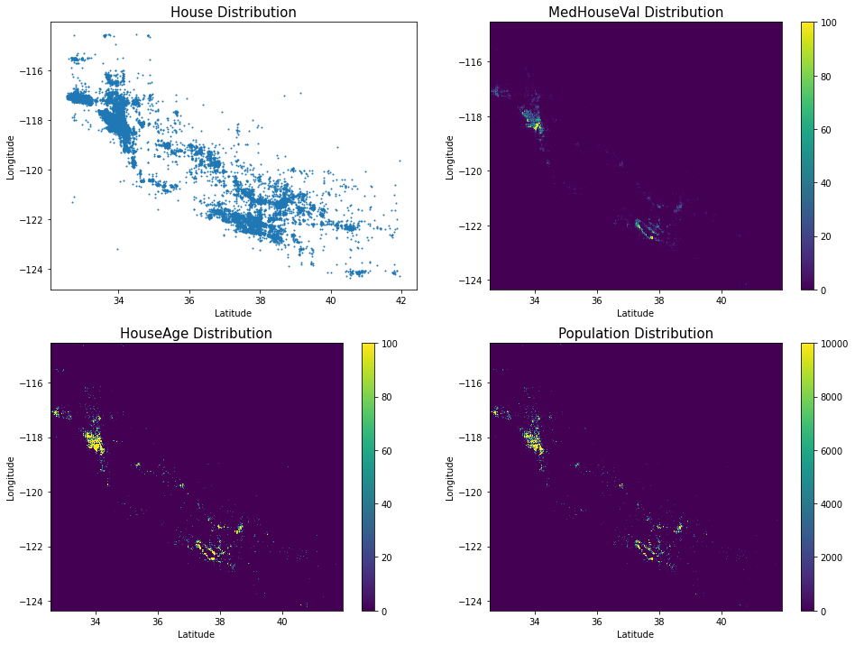

```python
f, ax= plt.subplots(figsize=(16,12), ncols=2, nrows=2)

ax[0,0].scatter(data_train['Latitude'], data_train['Longitude'], s=1)

h = ax[0,1].hist2d(x=data_train['Latitude'],
              y=data_train['Longitude'],
              weights=data_train['MedHouseVal'], bins = 500, vmin=0, vmax=100)
plt.colorbar(h[3], ax=ax[0,1])


h = ax[1,0].hist2d(x=data_train['Latitude'],
              y=data_train['Longitude'],
              weights=data_train['HouseAge'], bins = 1000, vmin=0, vmax=100)
plt.colorbar(h[3], ax=ax[1,0])


h = ax[1,1].hist2d(x=data_train['Latitude'],
              y=data_train['Longitude'],
              weights=data_train['Population'], bins = 1000, vmin=0, vmax=10000)
plt.colorbar(h[3], ax=ax[1,1])

for i in range(2):
    for j in range(2):
        ax[i,j].set_xlabel('Latitude'); ax[i,j].set_ylabel('Longitude')

ax[0,0].set_title('House Distribution', fontsize=15)
ax[0,1].set_title('MedHouseVal Distribution', fontsize=15)
ax[1,0].set_title('HouseAge Distribution', fontsize=15)
ax[1,1].set_title('Population Distribution', fontsize=15)

plt.show()
```

- MedHouseVal is greated as close as to San Francisco and Los Angeles cities. Similarly, both cities contains a great concentration of population and old houses.

## Distributions

It's alwas important to check your data distribution, that will give you a sense of which variables behave oddly and may require preprocessing. The following helper function will plot the mean value of the target column with the same scale of the generated histplots. It's a quick a fun way to visualize the relationships between the features and the target.

```python
def add_secondary_plot(
    df, column, target_column, ax, n_bins, color=3,
    show_yticks=False,
):
    secondary_ax = ax.twinx()
    bins = pd.cut(df[column], bins=n_bins)
    bins = pd.IntervalIndex(bins)
    bins = (bins.left + bins.right) / 2
    target = df.groupby(bins)[target_column].mean()
    target.plot(
        ax=secondary_ax, linestyle='',
        marker='.', color=colors[color], label=f'Mean {target_column}'
    )
    secondary_ax.grid(visible=False)

    if not show_yticks:
        secondary_ax.get_yaxis().set_ticks([])

    return secondary_ax
```

## Train Vs Test

**Insights:**

- There isn't notable differences between train and test, we probably do not need to do a in-depth adversarial validation.
- AveOccup, AveBdrms, AveRooms, Population have really skewed distributions, consider using clip function if there isn't a strong impact of outlier values. This may help especially for models that requires feature scaling.

```python
import matplotlib.colors as mpl_colors

def hex_to_rgb(h):
    h = h.lstrip('#')
    return tuple(int(h[i:i+2], 16)/255 for i in (0, 2, 4))

palette = ['#b4d2b1', '#568f8b', '#1d4a60', '#cd7e59', '#ddb247', '#d15252']
palette_rgb = [hex_to_rgb(x) for x in palette]
cmap = mpl_colors.ListedColormap(palette_rgb)
colors = cmap.colors
bg_color= '#fdfcf6'
```

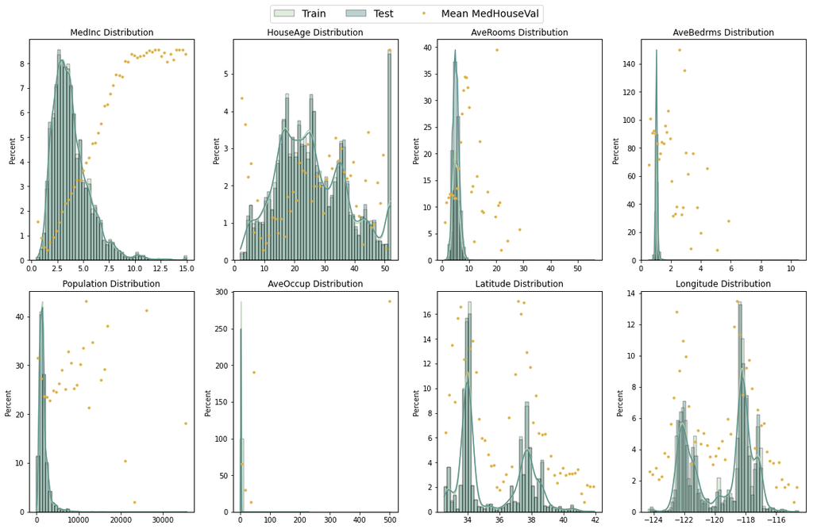

```python
n_bins = 50
histplot_hyperparams = {
    'kde':True,
    'alpha':0.4,
    'stat':'percent',
    'bins':n_bins
}

columns = features
fig, ax = plt.subplots(2, 4, figsize=(16, 10))
ax = ax.flatten()

for i, column in enumerate(columns):
    plot_axes = [ax[i]]

    sns.histplot(data_train[column], label='Train',
                 ax=ax[i], color=colors[0], **histplot_hyperparams)

    sns.histplot(data_test[column], label='Test',
                 ax=ax[i], color=colors[1], **histplot_hyperparams)

    # Secondary axis to show mean of target
    ax2 = add_secondary_plot(data_train, column, 'MedHouseVal', ax[i], n_bins, color=4)

    # titles
    ax[i].set_title(f'{column} Distribution');
    ax[i].set_xlabel(None)

    # remove axes to show only one at the end
    plot_axes = [ax[i], ax2]
    handles = []
    labels = []
    for plot_ax in plot_axes:
        handles += plot_ax.get_legend_handles_labels()[0]
        labels += plot_ax.get_legend_handles_labels()[1]
        plot_ax.legend().remove()

fig.legend(handles, labels, loc='upper center', bbox_to_anchor=(0.5, 1.04), fontsize=14, ncol=3)
plt.tight_layout()
```

## Correlations

```python
data_train.corr()['MedHouseVal'].sort_values(ascending=False)
```

```
MedHouseVal    1.000000
MedInc         0.701925
AveRooms       0.366727
HouseAge       0.103210
Population    -0.038479
AveOccup      -0.048475
Longitude     -0.056742
AveBedrms     -0.067487
Latitude      -0.116499
Name: MedHouseVal, dtype: float64
```

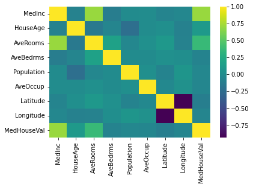

```python
sns.heatmap(data_train.corr(), cmap='viridis')
```

## Bivariate Distribution with Target

Even though correlations will give us a clear picture of linear relationships, it's also important to plot distribution to discover non relationships between variables and the target

### Train Dataset

**Insights:**

- Greater `MedInc` the greater the `MedHouseVal`, validated from correlations and from bivariate distribution, a similar effect can be seen on `AveRoooms` but is less evident.

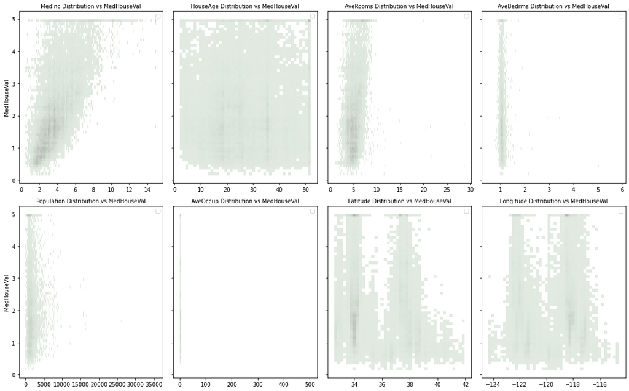

```python
histplot_hyperparams = {
    'kde':True,
    'alpha':0.4,
    'stat':'percent'
}

columns = features
fig, ax = plt.subplots(2, 4, figsize=(16, 10), sharey=True)
ax = ax.flatten()

for i, column in enumerate(columns):
    sns.histplot(x=data_train[column],
                 y=data_train['MedHouseVal'], label='Train', ax=ax[i], color=colors[0], **histplot_hyperparams)

    ax[i].set_title(f'{column} Distribution vs MedHouseVal', fontsize=10);
    ax[i].set_xlabel(None)
    ax[i].legend()

plt.tight_layout()
```

## Latitude And Longitude

**Insights**

- Data is distributed across the entire california state
- We can consider using socieconomic external data to have additional insights about geographic location
- Lots of properties in Los Angeles
- Train and test follow the same distribution of latitud-longitude pairs. random KFold Is enough

```python
import folium
from folium import plugins
from folium.plugins import HeatMap

heat_map = folium.Map(data_train[['Latitude', 'Longitude']].mean(axis=0), zoom_start = 6)

lat_long_list = [[ row['Latitude'],row['Longitude']] for index, row in data_train.iterrows()]
HeatMap(lat_long_list, radius=10).add_to(heat_map)
heat_map
```

Make this Notebook Trusted to load map: File -> Trust Notebook

[interactive chart not shown]

# Model Development

Catboost+XGBoost+LGBM

```python
import numpy as np # linear algebra
import pandas as pd # data processing, CSV file I/O (e.g. pd.read_csv)
from sklearn.model_selection import train_test_split
from sklearn.datasets import fetch_california_housing
```

```python
!pip install reverse_geocoder
```

```
     ━━━━━━━━━━━━━━━━━━━━━━━━━━━━━━━━━━━━━━━━ 2.2/2.2 MB 4.0 MB/s eta 0:00:00a 0:00:01
  Preparing metadata (setup.py) ... done
WARNING: Running pip as the 'root' user can result in broken permissions and conflicting behaviour with the system package manager. It is recommended to use a virtual environment instead: https://pip.pypa.io/warnings/venv
```

```python
train_df = pd.read_csv('/kaggle/input/playground-series-s3e1/train.csv')
test_df = pd.read_csv('/kaggle/input/playground-series-s3e1/test.csv')
submission = pd.read_csv('/kaggle/input/playground-series-s3e1/sample_submission.csv')
train_df = train_df.drop('id', axis=1)
```

```python
extra_data = fetch_california_housing()

train_data2 = pd.DataFrame(extra_data['data'])
train_data2['MedHouseVal'] = extra_data['target']
train_data2.columns = train_df.columns

train_df['generated'] = 1
test_df['generated'] = 1
train_data2['generated'] = 0

# train_df = pd.concat([train_df, train_data2],axis=0).drop_duplicates()
train_df = pd.concat([train_df, train_data2],axis=0, ignore_index=True)

train_df.loc[33228,['Latitude','Longitude']] = [32.74, -117]
train_df.loc[34363,['Latitude','Longitude']] = [32.71, -117]
train_df.loc[20991,['Latitude','Longitude']] = [34.2, -119]

print(train_df.shape)
train_df.head()
```

```
(57777, 10)
```

|  | MedInc | HouseAge | AveRooms | AveBedrms | Population | AveOccup | Latitude | Longitude | MedHouseVal | generated |
| --- | --- | --- | --- | --- | --- | --- | --- | --- | --- | --- |
| 0 | 2.3859 | 15.0 | 3.827160 | 1.112100 | 1280.0 | 2.486989 | 34.60 | -120.12 | 0.980 | 1 |
| 1 | 3.7188 | 17.0 | 6.013373 | 1.054217 | 1504.0 | 3.813084 | 38.69 | -121.22 | 0.946 | 1 |
| 2 | 4.7750 | 27.0 | 6.535604 | 1.103175 | 1061.0 | 2.464602 | 34.71 | -120.45 | 1.576 | 1 |
| 3 | 2.4138 | 16.0 | 3.350203 | 0.965432 | 1255.0 | 2.089286 | 32.66 | -117.09 | 1.336 | 1 |
| 4 | 3.7500 | 52.0 | 4.284404 | 1.069246 | 1793.0 | 1.604790 | 37.80 | -122.41 | 4.500 | 1 |

### Features

```python
train_df['r'] = np.sqrt(train_df['Latitude']**2 + train_df['Longitude']**2)
train_df['theta'] = np.arctan2(train_df['Latitude'], train_df['Longitude'])

test_df['r'] = np.sqrt(test_df['Latitude']**2 + test_df['Longitude']**2)
test_df['theta'] = np.arctan2(test_df['Latitude'], test_df['Longitude'])
```

```python
df = pd.concat([train_df, test_df], axis=0, ignore_index=True)
```

Encoding trick (see here: https://www.kaggle.com/competitions/playground-series-s3e1/discussion/376210)

```python
emb_size = 20
precision = 1e6

latlon = np.expand_dims(df[['Latitude', 'Longitude']].values, axis=-1)

m = np.exp(np.log(precision) / emb_size)
angle_freq = m ** np.arange(emb_size)
angle_freq = angle_freq.reshape(1, 1, emb_size)

latlon = latlon * angle_freq
latlon[..., 0::2] = np.cos(latlon[..., 0::2])
latlon[..., 1::2] = np.sin(latlon[..., 1::2])
latlon = latlon.reshape(-1, 2 * emb_size)

df['exp_latlon1'] = [lat[0] for lat in latlon]
df['exp_latlon2'] = [lat[1] for lat in latlon]
```

Using feature engineering ideas with coordinates suggested here: https://www.kaggle.com/code/dmitryuarov/ps-s3e1-coordinates-key-to-victory

```python
from sklearn.decomposition import PCA

def pca(data):
    '''
    input: dataframe containing Latitude(x) and Longitude(y)
    '''
    coordinates = data[['Latitude','Latitude']].values
    pca_obj = PCA().fit(coordinates)
    pca_x = pca_obj.transform(data[['Latitude', 'Longitude']].values)[:,0]
    pca_y = pca_obj.transform(data[['Latitude', 'Longitude']].values)[:,1]
    return pca_x, pca_y

# train_df['pca_x'], train_df['pca_y'] = pca(train_df)
# test_df['pca_x'], test_df['pca_y'] = pca(test_df)
df['pca_x'], df['pca_y'] = pca(df)
```

```python
from umap import UMAP

# UMAP: Uniform Manifold Approximation and Projection for Dimension Reduction
coordinates = df[['Latitude', 'Longitude']].values
umap = UMAP(n_components=2, n_neighbors=50, random_state=228).fit(coordinates)
df['umap_lat'] = umap.transform(coordinates)[:,0]
df['umap_lon'] = umap.transform(coordinates)[:,1]
```

```python
def crt_crds(df):
    df['rot_15_x'] = (np.cos(np.radians(15)) * df['Longitude']) + \
                      (np.sin(np.radians(15)) * df['Latitude'])

    df['rot_15_y'] = (np.cos(np.radians(15)) * df['Latitude']) + \
                      (np.sin(np.radians(15)) * df['Longitude'])

    df['rot_30_x'] = (np.cos(np.radians(30)) * df['Longitude']) + \
                      (np.sin(np.radians(30)) * df['Latitude'])

    df['rot_30_y'] = (np.cos(np.radians(30)) * df['Latitude']) + \
                      (np.sin(np.radians(30)) * df['Longitude'])

    df['rot_45_x'] = (np.cos(np.radians(45)) * df['Longitude']) + \
                      (np.sin(np.radians(45)) * df['Latitude'])
    return df

# train_df = crt_crds(train_df)
# test_df = crt_crds(test_df)
df = crt_crds(df)
```

```python
import reverse_geocoder as rg
from sklearn.preprocessing import LabelEncoder

def geocoder(df):
    coordinates = list(zip(df['Latitude'], df['Longitude']))
    results = rg.search(coordinates)
    return results

# results = geocoder(train_df)
# train_df['place'] = [x['admin2'] for x in results]
# results = geocoder(test_df)
# test_df['place'] = [x['admin2'] for x in results]

results = geocoder(df)
df['place'] = [x['admin2'] for x in results]

places = ['Los Angeles County', 'Orange County', 'Kern County',
          'Alameda County', 'San Francisco County', 'Ventura County',
          'Santa Clara County', 'Fresno County', 'Santa Barbara County',
          'Contra Costa County', 'Yolo County', 'Monterey County',
          'Riverside County', 'Napa County']

def replace(x):
    if x in places:
        return x
    else:
        return 'Other'

# train_df['place'] = train_df['place'].apply(lambda x: replace(x))
# test_df['place'] = test_df['place'].apply(lambda x: replace(x))

df['place'] = df['place'].apply(lambda x: replace(x))

# le = LabelEncoder()
# train_df['place'] = le.fit_transform(train_df['place'])
# test_df['place'] = le.transform(test_df['place'])

# test_df = pd.get_dummies(test_df)
# train_df = pd.get_dummies(train_df)

df = pd.get_dummies(df)
```

```
Loading formatted geocoded file...
```

Distances to cities and coast points

```python
from haversine import haversine

Sac = (38.576931, -121.494949)
SF = (37.780080, -122.420160)
SJ = (37.334789, -121.888138)
LA = (34.052235, -118.243683)
SD = (32.715759, -117.163818)

df['dist_Sac'] = df.apply(lambda x: haversine((x['Latitude'], x['Longitude']), Sac, unit='ft'), axis=1)
df['dist_SF'] = df.apply(lambda x: haversine((x['Latitude'], x['Longitude']), SF, unit='ft'), axis=1)
df['dist_SJ'] = df.apply(lambda x: haversine((x['Latitude'], x['Longitude']), SJ, unit='ft'), axis=1)
df['dist_LA'] = df.apply(lambda x: haversine((x['Latitude'], x['Longitude']), LA, unit='ft'), axis=1)
df['dist_SD'] = df.apply(lambda x: haversine((x['Latitude'], x['Longitude']), SD, unit='ft'), axis=1)
df['dist_nearest_city'] = df[['dist_Sac', 'dist_SF', 'dist_SJ',
                              'dist_LA', 'dist_SD']].min(axis=1)
```

```python
from shapely.geometry import LineString, Point

coast_points = LineString([(32.6644, -117.1613), (33.2064, -117.3831),
                           (33.7772, -118.2024), (34.4634, -120.0144),
                           (35.4273, -120.8819), (35.9284, -121.4892),
                           (36.9827, -122.0289), (37.6114, -122.4916),
                           (38.3556, -123.0603), (39.7926, -123.8217),
                           (40.7997, -124.1881), (41.7558, -124.1976)])

df['dist_to_coast'] = df.apply(lambda x: Point(x['Latitude'], x['Longitude']).distance(coast_points), axis=1)
```

```python
# combine latitude and longitude
# codes from
# https://datascience.stackexchange.com/questions/49553/combining-latitude-longitude-position-into-single-feature
from math import radians, cos, sin, asin, sqrt

def single_pt_haversine(lat, lng, degrees=True):
    """
    'Single-point' Haversine: Calculates the great circle distance
    between a point on Earth and the (0, 0) lat-long coordinate
    """
    r = 6371 # Earth's radius (km). Have r = 3956 if you want miles

    # Convert decimal degrees to radians
    if degrees:
        lat, lng = map(radians, [lat, lng])

    # 'Single-point' Haversine formula
    a = sin(lat/2)**2 + cos(lat) * sin(lng/2)**2
    d = 2 * r * asin(sqrt(a))

    return d
# add more metric
# referred to this discussion
# https://www.kaggle.com/competitions/playground-series-s3e1/discussion/376210

def manhattan(lat,lng):
    return np.abs(lat) + np.abs(lng)
def euclidean(lat,lng):
    return (lat**2 + lng**2) **0.5

def add_combine(df):
    df['haversine'] = [single_pt_haversine(x, y) for x, y in zip(df.Latitude, df.Longitude)]
    df['manhattan'] = [manhattan(x,y) for x,y in zip(df.Latitude, df.Longitude)]
    df['euclidean'] = [euclidean(x,y) for x,y in zip(df.Latitude,df.Longitude)]
    return df

df = add_combine(df)
```

```python
train_df = df.iloc[:-len(test_df),:]
test_df = df.iloc[-len(test_df):,:].drop('MedHouseVal', axis=1).reset_index(drop=True)

X = train_df.drop(['MedHouseVal', 'id'], axis=1)
y = train_df.MedHouseVal
X_test = test_df.drop('id', axis=1)
```

### Catboost model

```python
import catboost
from sklearn.model_selection import KFold
from sklearn.metrics import mean_squared_error

n_folds = 15

MAX_ITER = 15000
PATIENCE = 1000
DISPLAY_FREQ = 100

eval_predsCB = []
predsCB = []

k_fold = KFold(n_splits=n_folds, random_state=42, shuffle=True)

MODEL_PARAMS = {
                'random_seed': 1234,
#                 'learning_rate': 0.1,   # 0.15: 0.5678, 0.12: 0.5685, 0.1: 0.56757, 0.05: 0.57, 0.01, 0.57
                'iterations': MAX_ITER,
                'early_stopping_rounds': PATIENCE,
#                 'metric_period': DISPLAY_FREQ,
                'use_best_model': True,
                'eval_metric': 'RMSE',
                'verbose': 1000,
#                 'task_type': 'GPU'
               }


for train_index, test_index in k_fold.split(X, y):
    X_train, X_valid = X.iloc[train_index], X.iloc[test_index]
    y_train, y_valid = y.iloc[train_index], y.iloc[test_index]

    model = catboost.CatBoostRegressor(**MODEL_PARAMS)

    model.fit(X=X_train, y=y_train,
          eval_set=[(X_valid, y_valid)],
          early_stopping_rounds = PATIENCE,
#           metric_period = DISPLAY_FREQ
         )
    predsCB.append(model.predict(X_test))
#     eval_predsCB.append(model.predict(X))
#     print("RMSE valid = {}".format(mean_squared_error(y_valid, model.predict(X_valid))))
#     print("RMSE full = {}".format(mean_squared_error(y, model.predict(X))))
```

### XGBoost model

```python
from xgboost import XGBRegressor

# n_folds = 20
k_fold = KFold(n_splits=n_folds, random_state=42, shuffle=True)

eval_predsXB = []
predsXB = []

PATIENCE = 200

MODEL_PARAMS = {       'n_estimators': 1000, #1000, 5000
#                        'learning_rate': 0.05,
                       'max_depth': 4, # 3
                       'colsample_bytree': 0.9, # 0.95
                       'subsample': 1,
                       'reg_lambda': 20,
                       'early_stopping_rounds': PATIENCE,
#                        'tree_method': 'gpu_hist',
                       'seed': 1
}

for train_index, test_index in k_fold.split(X, y):
    X_train, X_valid = X.iloc[train_index], X.iloc[test_index]
    y_train, y_valid = y.iloc[train_index], y.iloc[test_index]

    model = XGBRegressor(**MODEL_PARAMS)

    model.fit(X=X_train, y=y_train,
          eval_set=[(X_valid, y_valid)],
#           early_stopping_rounds = PATIENCE,
          verbose = 100
         )
    predsXB.append(model.predict(X_test))
#     eval_predsXB.append(model.predict(X))
```

### LGBM model

```python
import lightgbm as lgbm
from lightgbm.sklearn import LGBMRegressor

# n_folds = 20
k_fold = KFold(n_splits=n_folds, random_state=42, shuffle=True)

eval_predsLB = []
predsLB = []

MODEL_PARAMS = {
                       'learning_rate': 0.01,
                       'max_depth': 9,
                       'num_leaves': 90,
                       'colsample_bytree': 0.8,
                       'subsample': 0.9,
                       'subsample_freq': 5,
                       'min_child_samples': 36,
                       'reg_lambda': 28,
                       'n_estimators': 20000,
                       'metric': 'rmse',
                       'random_state': 1
}

callbacks = [lgbm.early_stopping(30, verbose=1), lgbm.log_evaluation(period=0)]

for train_index, test_index in k_fold.split(X, y):
    X_train, X_valid = X.iloc[train_index], X.iloc[test_index]
    y_train, y_valid = y.iloc[train_index], y.iloc[test_index]

    model = lgbm.LGBMRegressor(**MODEL_PARAMS)

    model.fit(X=X_train, y=y_train,
          eval_set=[(X_valid, y_valid)],
#           early_stopping_rounds = PATIENCE,
          callbacks=callbacks
         )
    predsLB.append(model.predict(X_test))
#     eval_predsLB.append(model.predict(X))
```

### Making prediction

```python
a = 0.4
b = 0.2
c = 0.4

predCB = np.average(np.array(predsCB),axis=0)
predXB = np.average(np.array(predsXB),axis=0)
predLB = np.average(np.array(predsLB),axis=0)
pred = predCB * a + predXB * b + predLB * c
```

### Making submission

```python
submission['MedHouseVal'] = pred
submission
```

```python
vals = train_df['MedHouseVal'].unique().tolist()
submission['MedHouseVal'] = submission['MedHouseVal'].apply(lambda x: min(vals, key=lambda v: abs(v - x)))
submission.MedHouseVal.clip(0, 5, inplace=True)
```

```python
submission.to_csv('submission_v3.1.4.csv', index=False)
```